# AMEDA workflow: an introducing tutorial

This notebook will show you how to use AMEDA (1) on AVISO dataset and also help you to produce some figures of one specific day.

I. Create tools and directories

II. Get AVISO netcdf

III. Run AMEDA

IV. Produce some plot

V. Export tracks as netcdf

NB: The notebook need python and matlab to work properly

(1) Le Vu, B., Stegner, A. and Arzouse, T. Angular Momentum Eddy Detection and tracking Algorithm (AMEDA) and its application to coastal eddy formation. To be submitted to Journal of Atmospheric and Ocean Technology.

## I. Create tools and directories

**Define directories to run the tutorial as *homedir***

```python
homedir = '/home/blevu/Tuto/'

workdir = homedir+'AMEDA/'
datadir = homedir+'DATA/'
outdir = homedir+'RESULT/'
```

**Produce script which create directories, copy code and produce pre- and post-processing tools**  
This cell convert _make*tools.ipynb* into python script which copy code and tools and produce specific tools such as AVISO and PODAAC data  
NB: If you want to modify the make_tools modify _make*tools.ipynb* first

```python
%cd $homedir
!jupyter nbconvert --to script make_tools.ipynb
```

```
/home/blevu/Tuto
[NbConvertApp] Converting notebook make_tools.ipynb to script
[NbConvertApp] Writing 22140 bytes to make_tools.py
```

**Run _make*tools.py* as a script</**

```python
%cd $homedir
%run make_tools.py
```

```
/home/blevu/Tuto
mkdir: cannot create directory `/home/blevu/Tuto/AMEDA/': File exists
mkdir: cannot create directory `/home/blevu/Tuto/DATA/': File exists
mkdir: cannot create directory `/home/blevu/Tuto/RESULT/': File exists
Overwriting /home/blevu/Tuto/keys_sources_AVISO_Tuto.m
Overwriting /home/blevu/Tuto/MAIN_AMEDA_Tuto.m
Overwriting /home/blevu/Tuto/DATA/get_aviso.sh
Overwriting /home/blevu/Tuto/DATA/mk_nc_file.m
Overwriting /home/blevu/Tuto/DATA/get_podaac.sh
```

## II. Get data netcdf

**Choose the date you want to analyse and write it in a file**

```python
date='20161025'

import datetime as dt
t1 = dt.datetime.strptime(date,'%Y%m%d')
dt=t1-dt.datetime(t1.year-1,12,31)

f=open(datadir+'date.txt','w+')
f.write(date + '\n')
f.close()

f=open(datadir+'date_jj.txt','w+')
f.write(str(dt.days) + '\n')
f.close()
```

**Download AVISO files at the *date* (gridded and tracks)**

```python
%cd $datadir
!sh get_aviso.sh
```

[output not shown]

[output cut: 94 more lines]

[output not shown]

**Convert the AVISO gridded file to AMEDA input files**

```python
%cd $datadir
!matlab -nodesktop -nodisplay < mk_nc_file.m
```

[output not shown]

**Download PODAAC files at the *date***

```python
%cd $datadir
!sh get_podaac.sh
```

[output not shown]

[output cut: 95 more lines]

```

FINISHED --2016-12-09 14:04:38--
Downloaded: 2 files, 38M in 17s (2.24 MB/s)
./20161025020000-OSISAF-L3C_GHRSST-SSTsubskin-VIIRS_SST_NPP_NAR-sstnar_npp_20161025_020000-v02.0-fv01.0.nc
cdo select (Warning): Variable name >lat< not found!
cdo select (Warning): Variable name >lon< not found!
cdo select: Processed 12582912 values from 16 variables over 1 timestep ( 3.08s )
cdo selindexbox: Processed 12582912 values from 1 variable over 1 timestep ( 2.33s )
./20161025130000-OSISAF-L3C_GHRSST-SSTsubskin-VIIRS_SST_NPP_NAR-sstnar_npp_20161025_130000-v02.0-fv01.0.nc
cdo select (Warning): Variable name >lat< not found!
cdo select (Warning): Variable name >lon< not found!
cdo select: Processed 12582912 values from 16 variables over 1 timestep ( 2.42s )
cdo selindexbox: Processed 12582912 values from 1 variable over 1 timestep ( 1.47s )
cdo copy: Processed 3405702 values from 2 variables over 2 timesteps ( 0.42s )
cdo mergetime: Processed 10217106 values from 3 variables over 6 timesteps ( 0.86s )
```

## III. Run AMEDA

**Execute MATLAB in batch**

```python
%cd $homedir
# run the code
!matlab -nodesktop -nodisplay < MAIN_AMEDA_Tuto.m
```

```
/home/blevu/Tuto

                            < M A T L A B (R) >
                  Copyright 1984-2014 The MathWorks, Inc.
                    R2014a (8.3.0.532) 64-bit (glnxa64)
                             February 11, 2014


To get started, type one of these: helpwin, helpdesk, or demo.
For product information, visit www.mathworks.com.

>> >> >> >> >> >> >> >> >> >> >> >> >> >> >> >> >> >> >> >> >> >> >> >> >> >> >> >> >> >> >> >> >> >> >> >> >> >> >> >> >> >> >> >> >> >> >> >> >> >> >> >> >> >> >> >> >> >>
To get started, type one of these: helpwin, helpdesk, or demo.
For product information, visit www.mathworks.com.

>> >> >> >> >> >> >> >> >> >> >> >> >> >> >> >> >> >> >> >> >> >> >> >> >> Compute from /home/blevu/Tuto/DATA/
 to /home/blevu/Tuto/RESULT/adt_20161025//
 1 time steps

>> Compute from /home/blevu/Tuto/DATA/
 to /home/blevu/Tuto/RESULT/adt_20161025//
 1 time steps

>> >> >> >> >> >> >> >> >> >> >> >>  === Compute non interpolated LNAM ===
>>
>> >> >> >>  <<< Compute fields step 1
Get grid and velocities field at step 1 ...
Enlarge coastal mask by adding 1 pixels of ocean to the coast ...
NO INTERPOLATION
Compute LNAM >>>

>> >> >> >> >> >> >> >> >> >>  === Compute interpolated LNAM ===

 <<< Compute fields step 1
Get grid and velocities field at step 1 ...
Enlarge coastal mask by adding 1 pixels of ocean to the coast ...
Change resolution by computing 2D SPLINE INTERPOLATION by a factor 3
Compute LNAM >>>

>> >> >> >> >> >> >> >> >> >> >>  === Find potential centers ===
```

[output cut: 991 more lines]

```
Save tracks in eddy_tracks.mat ...

>> >> >> >> Load tracks ...
Find merging and splitting of the interacting eddies among the 211 eddies ...

Filter eddies shorter than their turnover time ...
 209 eddies remaining
 adjust interaction indice and clean shapes2 ...
  eddy 72 is still interacting with 2 eddies 76  63 on step 1
  eddy 76 is still interacting with 2 eddies 72  72 on step 1

 then clean double shapes with no interaction ...

Save tracks2 in eddy_tracks.mat ...
>>
```

**Load AMEDA output using octave**

```python
from oct2py import octave
%load_ext oct2py.ipython
```

```python
keys_source = homedir+'keys_sources_AVISO_Tuto'
print(homedir+'keys_sources_AVISO_Tuto')
%octave_push datadir outdir keys_source
#%octave run(keys_source)
```

```
/home/blevu/Tuto/keys_sources_AVISO_Tuto
```

```python
%%octave -i datadir,outdir,keys_source -o x,y,tracks2
% set name of the domain
domain='MED';

% use to diferenciate source field of surface height (adt, ssh, psi,...)
sshtype='adt'; % adt or sla

% set the paths
postname = textread([datadir,'date.txt'],'%s');
path_out=[outdir,sshtype,'_',postname{1,1},'/'];

% load parameters and grid
load([path_out,'param_eddy_tracking'])
load([path_out,'eddy_tracks2'])
```

**Load fields output using scipy and np**

```python
import scipy.io as sio
import numpy as np
mat_contents = sio.loadmat(outdir+'adt_'+date+'/fields.mat')
param_contents = sio.loadmat(outdir+'adt_'+date+'/param_eddy_tracking.mat')
tracks_contents = sio.loadmat(outdir+'adt_'+date+'/eddy_tracks2.mat', squeeze_me=True)
print(sio.whosmat(outdir+'adt_'+date+'/fields.mat'))
print(sio.whosmat(outdir+'adt_'+date+'/param_eddy_tracking.mat'))
print(sio.whosmat(outdir+'adt_'+date+'/eddy_tracks2.mat'))
```

```
[('detection_fields', (1, 1), 'struct')]
[('stepF', (1, 1), 'double'), ('nc_dim', (1,), 'char'), ('x_name', (1,), 'char'), ('y_name', (1,), 'char'), ('deg', (1, 1), 'double'), ('x', (128, 344), 'double'), ('y', (128, 344), 'double'), ('grid_ll', (1, 1), 'double'), ('Dx', (128, 344), 'double'), ('T', (1, 1), 'double'), ('f', (1, 1), 'double…
[('short', (1, 211), 'logical'), ('tracks2', (1, 209), 'struct')]
```

```python
# put a structure in a array of array
fields_struct = mat_contents['detection_fields']
print(fields_struct.dtype.names)
tracks_struct = tracks_contents['tracks2']
print(tracks_struct.dtype.names)
```

```
('step', 'ke', 'div', 'vort', 'OW', 'LOW', 'LNAM')
('step', 'type', 'x1', 'y1', 'x2', 'y2', 'dc', 'ind2', 'shapes1', 'velmax1', 'tau1', 'deta1', 'nrho1', 'rmax1', 'aire1', 'shapes3', 'velmax3', 'deta3', 'rmax3', 'aire3', 'alpha', 'rsquare', 'rmse', 'xbary1', 'ybary1', 'ellip1', 'ke1', 'vort1', 'vortM1', 'OW1', 'LNAM1', 'shapes2', 'velmax2', 'deta2',…
```

```python
# get computed fields
step = fields_struct[0,0]['step']
vort = fields_struct[0,0]['vort']
LNAM = fields_struct[0,0]['LNAM']
LOW = fields_struct[0,0]['LOW']
print(LOW.shape)
```

```
(128, 344)
```

## IV. Produce some plots

**Load *u, v, ssh* using netcdf4**

```python
import datetime
from netCDF4 import Dataset
```

```python
# load AVISO data
file = datadir+'ssh_adt_MED_'+date+'.nc'
data = Dataset(file, mode='r')
ssh = data.variables['ssh'][:]
file = datadir+'ssu_adt_MED_'+date+'.nc'
data = Dataset(file, mode='r')
ssu = data.variables['u'][:]
file = datadir+'ssv_adt_MED_'+date+'.nc'
data = Dataset(file, mode='r')
ssv = data.variables['v'][:]
file = datadir+'lon_lat_adt_MED.nc'
data = Dataset(file, mode='r')
xgrid = data.variables['lon'][:]
ygrid = data.variables['lat'][:]
mask = data.variables['mask'][:]
data.close()
```

```python
# meshgrid coordinates of the native grid
ssh = np.squeeze(ssh)
ssu = np.squeeze(ssu)
ssv = np.squeeze(ssv)
print(xgrid.shape)
print(ssu.shape)
```

```
(128, 344)
(128, 344)
```

**Plot various background map**

```python
import datetime as dt
import matplotlib.pyplot as plt
from mpl_toolkits.basemap import Basemap, shiftgrid
import matplotlib.colors as mplc
```

Plot LNAM over the global Mediterranean

```python
# make Hobo Dyer projection: Cylindric Equal Area and circle at 37.5°
# llcrnrlat,llcrnrlon,urcrnrlat,urcrnrlon are the lat/lon values of
# the lower left and upper right corners of the map.
# resolution = 'c' means use crude resolution coastlines. 'i' intermediate, 'h' high
m = Basemap(resolution='i',projection='cea', lat_ts=37.5,\
            llcrnrlat=30,urcrnrlat=46,\
            llcrnrlon=-6,urcrnrlon=37)
# create figure, add axes
fig1 = plt.figure(figsize=(10,4))
ax = fig1.add_axes([0.1,0.1,0.8,0.8])
# draw coastline
m.drawcoastlines()
m.fillcontinents(color='0.9',lake_color='none')
# draw parallels and meridians.
# label parallels on left and top
m.drawparallels(np.arange(30.,50.,2.),labels=[True,False,True,False])
# meridians on bottom and left
# labels = [left,right,top,bottom]
m.drawmeridians(np.arange(-10.,40.,5.),labels=[True,False,False,True])
#m.drawmapboundary(fill_color='aqua')
# set desired contour levels.
clevs = np.arange(-1,1,0.05)
# project native x,y coordinates of grid.
x, y = m(xgrid, ygrid)
# plot SLP contours.
CS1 = m.contourf(x,y,LNAM,clevs,cmap=plt.cm.RdBu_r)
CS2 = m.contour(x,y,LNAM,(-0.7,0.7),linewidths=0.5,colors='k',animated=True)
# Make a colorbar for the ContourSet returned by the contourf call.
cbar = m.colorbar(CS1,location='right',pad="5%",label='LNAM')
```

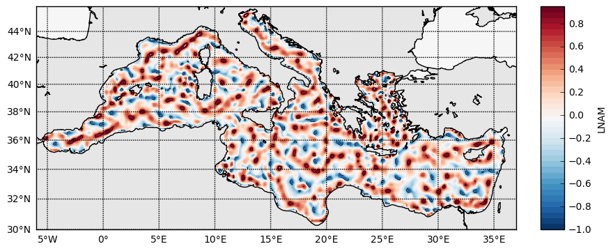

```python
# Print map at screen
plt.show()
```

```python
# make Hobo Dyer projection: Cylindric Equal Area and circle at 37.5°
# llcrnrlat,llcrnrlon,urcrnrlat,urcrnrlon are the lat/lon values of
# the lower left and upper right corners of the map.
# resolution = 'c' means use crude resolution coastlines. 'i' intermediate, 'h' high
mw = Basemap(resolution='i',projection='cea', lat_ts=40,\
            llcrnrlat=36,urcrnrlat=45,\
            llcrnrlon=0,urcrnrlon=10)
# create figure, add axes
fig1 = plt.figure(figsize=(8,6))
ax = fig1.add_axes([0.1,0.1,0.8,0.8])
# draw coastline
mw.drawcoastlines()
mw.fillcontinents(color='0.9',lake_color='none')
# draw parallels and meridians.
# label parallels on left and top
mw.drawparallels(np.arange(30.,50.,2.),labels=[True,False,True,False])
# meridians on bottom and left
# labels = [left,right,top,bottom]
mw.drawmeridians(np.arange(-10.,40.,5.),labels=[True,False,False,True])
#m.drawmapboundary(fill_color='aqua')
# set desired contour levels.
clevs = np.arange(-2,2,0.1)*1e-10
# project native x,y coordinates of grid.
x, y = mw(xgrid, ygrid)
# plot SLP contours.
#norm = mplc.Normalize(-5.*1e-10, 5.*1e-10)
CS1 = mw.contourf(x,y,LOW,clevs,cmap=plt.cm.seismic,\
                  #norm=norm,\
                  extend="both")
#CS2 = mw.contour(x,y,LOW,linewidths=0.5,colors='k',animated=True)
# colorbar
# Make a colorbar for the ContourSet returned by the contourf call.
cbar = mw.colorbar(CS1,location='right',pad="5%",label='VORT')
```

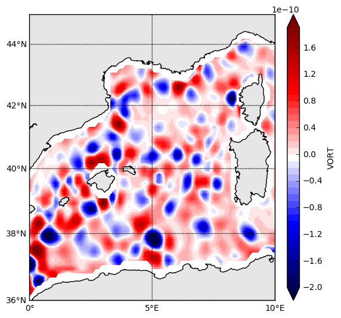

```python
# Print map at screen
plt.show()
```

Plot ADT and velocities in Eastern basin

```python
# make Hobo Dyer projection: Cylindric Equal Area and circle at 37.5°
# llcrnrlat,llcrnrlon,urcrnrlat,urcrnrlon are the lat/lon values of
# the lower left and upper right corners of the map.
# resolution = 'c' means use crude resolution coastlines. 'i' intermediate, 'h' high
mw = Basemap(resolution='i',projection='cea', lat_ts=33,\
            llcrnrlat=30,urcrnrlat=36,\
            llcrnrlon=18,urcrnrlon=30)
# create figure, add axes
fig1 = plt.figure(figsize=(8,6))
ax = fig1.add_axes([0.1,0.1,0.8,0.8])
# draw coastline
mw.drawcoastlines()
mw.fillcontinents(color='0.9',lake_color='none')
# draw parallels and meridians.
# label parallels on left and top
mw.drawparallels(np.arange(30.,50.,2.),labels=[True,False,True,False])
# meridians on bottom and left
# labels = [left,right,top,bottom]
mw.drawmeridians(np.arange(-10.,40.,5.),labels=[True,False,False,True])
#m.drawmapboundary(fill_color='aqua')
# set desired contour levels.
clevs = np.arange(-15,25,0.5)
# project native x,y coordinates of grid.
x, y = mw(xgrid, ygrid)
# plot SLP contours.
#norm = mplc.Normalize(-5.*1e-10, 5.*1e-10)
CS1 = mw.contourf(x,y,ssh*100,clevs,cmap=plt.cm.Spectral,extend="both")
#CS2 = mw.contour(x,y,LOW,linewidths=0.5,colors='k',animated=True)
# transform vectors to projection grid.
uproj,vproj,xx,yy = \
mw.transform_vector(ssu,ssv,xgrid[1,:],ygrid[:,1],50,30,returnxy=True,masked=False)
# Plot Velocities
Q = mw.quiver(xx,yy,uproj,vproj,scale=10)
# make quiver key.
qk = plt.quiverkey(Q, 0.9, 0.1, 0.5, '0.5 m/s', labelpos='W')
# colorbar
# Make a colorbar for the ContourSet returned by the contourf call.
cbar = mw.colorbar(CS1,location='right',pad="5%",label='ADT(cm)')
# date in teh title
ax.set_title('ADT and velocities '+str(dt.datetime.strptime(date,'%Y%m%d').strftime('the %d, %b %Y')))
```

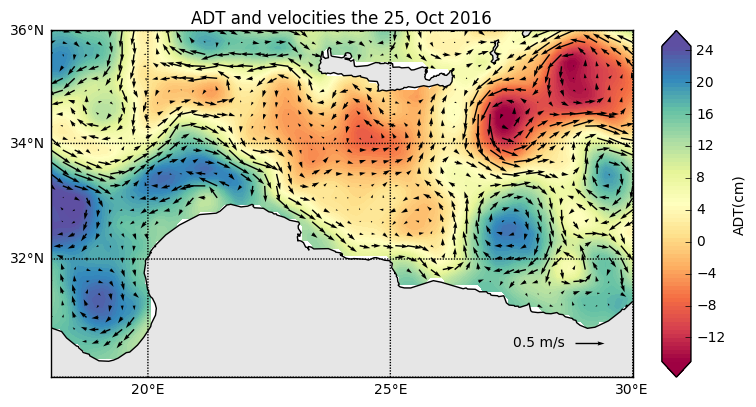

```python
# Print map at screen
plt.show()
```

**Plot AMEDA results**

```python
# make Hobo Dyer projection: Cylindric Equal Area and circle at 37.5°
# llcrnrlat,llcrnrlon,urcrnrlat,urcrnrlon are the lat/lon values of
# the lower left and upper right corners of the map.
# resolution = 'c' means use crude resolution coastlines. 'i' intermediate, 'h' high
mw = Basemap(resolution='i',projection='cea', lat_ts=33,\
            llcrnrlat=30,urcrnrlat=36,\
            llcrnrlon=18,urcrnrlon=30)
# create figure, add axes
fig1 = plt.figure(figsize=(10,8))
ax = fig1.add_axes([0.1,0.1,0.8,0.8])
# draw coastline
mw.drawcoastlines()
mw.fillcontinents(color='0.9',lake_color='none')
# draw parallels and meridians.
# label parallels on left and top
mw.drawparallels(np.arange(30.,50.,2.),labels=[True,False,True,False])
# meridians on bottom and left
# labels = [left,right,top,bottom]
mw.drawmeridians(np.arange(-10.,40.,5.),labels=[True,False,False,True])
#m.drawmapboundary(fill_color='aqua')
# set desired contour levels.
clevs = np.arange(-15,25,0.5)
# project native x,y coordinates of grid.
x, y = mw(xgrid, ygrid)
# plot SLP contours.
#norm = mplc.Normalize(-5.*1e-10, 5.*1e-10)
CS1 = mw.contourf(x,y,ssh*100,clevs,cmap=plt.cm.Spectral_r,extend="both")
#CS2 = mw.contour(x,y,LOW,linewidths=0.5,colors='k',animated=True)
# transform vectors to projection grid.
uproj,vproj,xx,yy = \
mw.transform_vector(ssu,ssv,xgrid[1,:],ygrid[:,1],50,30,returnxy=True,masked=False)
# Plot Velocities
Q = mw.quiver(xx,yy,uproj,vproj,scale=10)
# make quiver key.
qk = plt.quiverkey(Q, 0.9, 0.1, 0.5, '0.5 m/s', labelpos='W')
# colorbar
# Make a colorbar for the ContourSet returned by the contourf call.
cbar = mw.colorbar(CS1,location='right',pad="5%",label='ADT(cm)')
# date in teh title
ax.set_title('ADT and velocities '+str(dt.datetime.strptime(date,'%Y%m%d').strftime('the %d, %b %Y')))
# Draw eddies
xC,yC = mw(tracks_struct['x1'],tracks_struct['y1'])
mw.scatter(xC,yC,marker='o',c='w',edgecolor='k',s=10)
for i in range(tracks_struct['type'].shape[0]):
    lonlat1 = tracks_struct['shapes1'][i]
    x1, y1 = mw(lonlat1[0,:], lonlat1[1,:])
    if tracks_struct['type'][i] == -1:
        col=(.1,.1,.9); # anticyclone
    else:
        col=(.9,.1,.1); # cyclone
    if tracks_struct['calcul'][i] == 1:
        col=(col[0],col[1]+.4,col[2]); # calculated contour
    if tracks_struct['large1'][i] == 0:
        wid='-'; # largest eddy
    else:
        wid='--'; # true eddy
    mw.plot(x1,y1,ls=wid,color=col,lw=2)
```

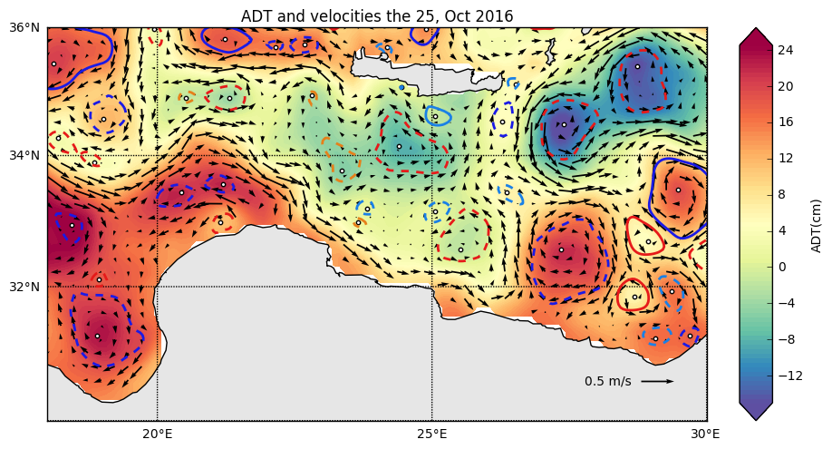

```python
# Print map at screen
plt.show()
```

**Figure 1**: AMEDA results for eddies detection for the 25th, october of 2016 in the Levantin basin with eddies centers (white dots), cyclones (red and orange contours) and anticlyclone (blue and light blue contours). Arrow for the surface geostrophic velocity filed, gridded at 1/8°, derived from the ADT (background colormap).